## # Reproducible Research - Project course 1

author: “Manuel” date: Mon Apr 27 17:32:22 2020 output: html_document —

## Loading and preprocessing the data

```r
# As starting point I will create a directory ("data") where load the .zip file
if (!file.exists('data')){
    dir.create('data')
}

# And as next step I will download the information keeping record on when was downloaded
fileURL <- "https://d396qusza40orc.cloudfront.net/repdata%2Fdata%2Factivity.zip"
download.file(fileURL,destfile = 'data/data_project.zip')
unzip('data/data_project.zip',exdir = './data')
date_of_download <- date()

# Reading the input file and converting date column from factor to date
activity=read.csv("./data/activity.csv")
activity$date<-as.Date(activity$date)
```

Data has been loaded from https://d396qusza40orc.cloudfront.net/repdata%2Fdata%2Factivity.zip on Mon Apr 27 17:32:23 2020

## What is mean total number of steps taken per day?

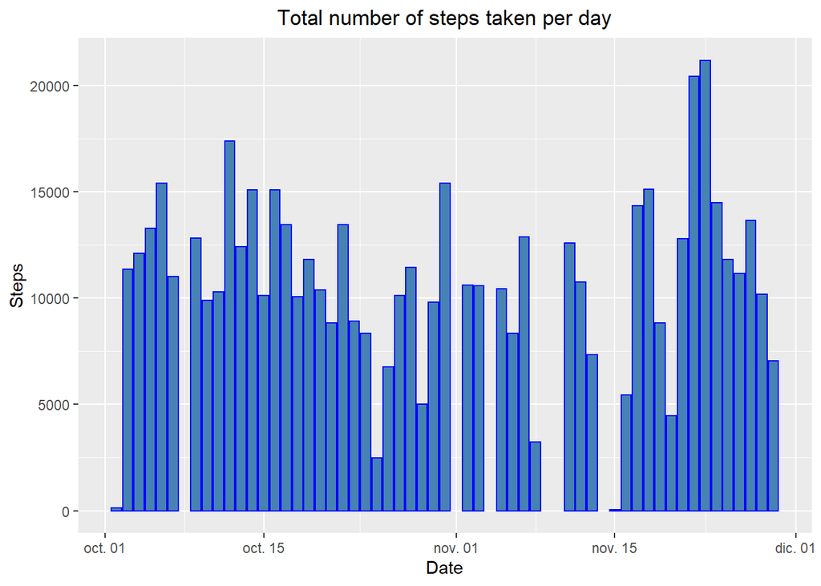

```r
# Firstly I calculate the data I need to show in the histogram and required values
stepsday<-aggregate(steps ~ date, activity,sum)         # total steps/days
stepsmean<-aggregate(steps ~ date, activity,mean)       # mean steps/day
stepsmedian<-aggregate(steps ~ date, activity,median)   # median steps/day

library(ggplot2)
# I set centered the title of becoming plots
theme_update(plot.title = element_text(hjust = 0.5))
# Create the histogram of number of steps per day
ggplot(data=data.frame(stepsday), mapping = aes(x=date, y=steps)) +
     geom_bar(stat = "identity", color="blue", fill="steelblue") +
     labs(x="Date")+
     labs(y="Steps")+
     ggtitle("Total number of steps taken per day")
```

## What is the average daily activity pattern?

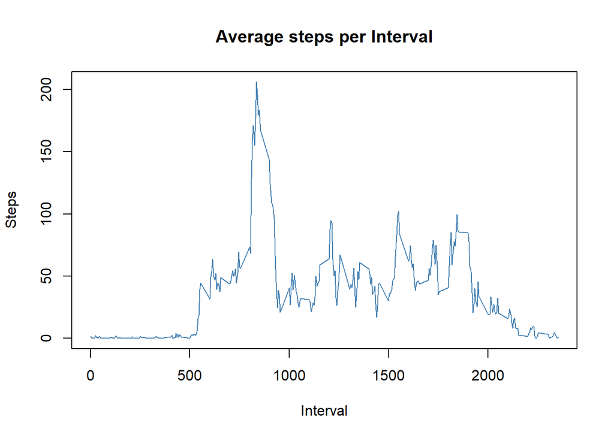

```r
# get a data frame with the average of steps per interval
stepsIntervalmean<-aggregate(steps ~ interval, activity,mean)

plot(stepsIntervalmean$interval, stepsIntervalmean$steps ,
     type="l",
     xlab="Interval",
     col="steelblue",
     ylab="Steps",
     main="Average steps per Interval")
```

```r
# I extract from the data frame the row which columne step has the max value
maxIntervalSteps<-stepsIntervalmean[stepsIntervalmean$steps ==
                      max(stepsIntervalmean$steps,
                          na.rm = TRUE),]
```

**835** is the *5-minute interval*, on average across all the days in the dataset, which contains the maximum number of steps

## Imputing missing values

```r
# Firstly I extract the total number of missing values in the dataset
missingValues=sum(is.na(activity))
```

The total number of *missing values* in the dataset is **2304**

So in order to fill this missing value I use the following *strategy*: I will use the mean of the interval and will create a new dataframe that is equal to the original dataset but with the missing data filled in.

```r
# Create a new data frame mergin the activity data frame and the data frame which
# contains step means by interval
newactivity=merge(activity, stepsIntervalmean, by="interval")

# Replace NA interval step values by the mean of steps
newactivity$steps.x <- ifelse(is.na(newactivity$steps.x),
                            newactivity$steps.y,
                            newactivity$steps.x)
```

```r
library(ggpubr)
```

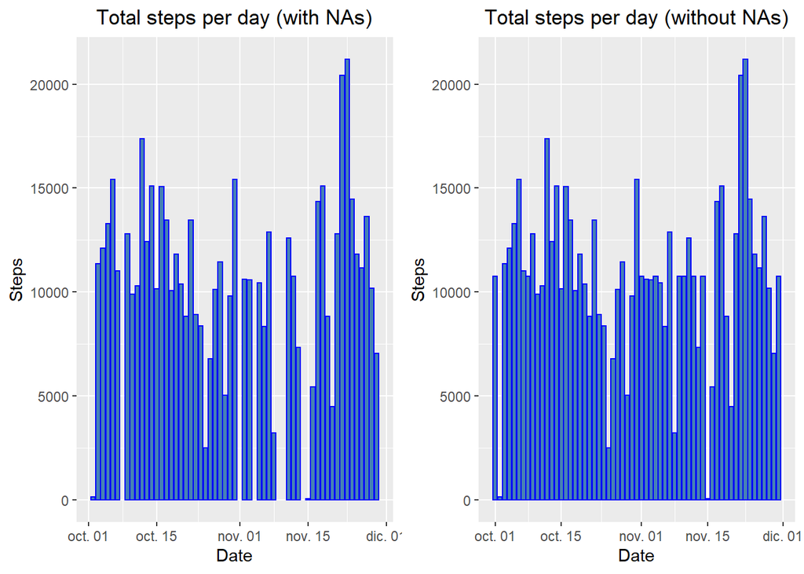

```r
newstepsday<-aggregate(steps.x ~ date, newactivity,sum)         # total steps/days
newstepsmean<-aggregate(steps.x ~ date, newactivity,mean)       # mean steps/day
newstepsmedian<-aggregate(steps.x ~ date, newactivity,median)   # median steps/day

hist1<-ggplot(data=data.frame(stepsday), mapping = aes(x=date, y=steps)) +
    geom_bar(stat = "identity", color="blue", fill="steelblue") +
    labs(x="Date")+
    labs(y="Steps")+
    ggtitle("Total steps per day (with NAs)")
hist2<-ggplot(data=data.frame(newstepsday), mapping = aes(x=date, y=steps.x)) +
    geom_bar(stat = "identity", color="blue", fill="steelblue") +
    labs(x="Date")+
    labs(y="Steps")+
    ggtitle("Total steps per day (without NAs)")
ggarrange(hist1, hist2,
          ncol = 2, nrow = 1)
```

## Are there differences in activity patterns between weekdays and weekends?

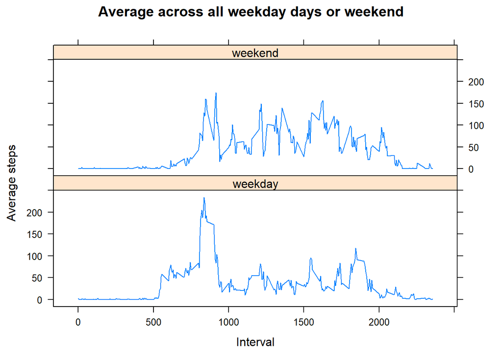

```r
#First I create a column with the day of the date
activity=cbind(weekday=weekdays(activity$date),activity)

# Identify and replace weekday name by "weekday" or "weekend" values
activity$weekday <- ifelse(activity$weekday %in% c("sábado", "domingo"),
                              "weekend",
                              "weekday")

stepsIntervalWeekday<-aggregate(steps ~ interval+weekday, activity,mean)

library(lattice)
xyplot(steps ~ interval | weekday,
       data = stepsIntervalWeekday,
       type="l",
       layout = c(1, 2),
       main="Average across all weekday days or weekend",
       xlab = "Interval",
       ylab = "Average steps")
```